# Risk Factor Analysis

## Outcome Variable

**Outcome Variable:** whz

## Predictor Variables

**Intervention Variable:** trth2o

**Adjustment Set:**

- arm
- sex
- W_mage
- meducyrs
- feducyrs
- hfoodsec
- W_mhtcm
- W_mwtkg
- W_mbmi
- W_nrooms
- W_nhh
- W_nchldlt5
- cleanck
- impfloor
- impsan
- safeh20
- delta_meducyrs
- delta_feducyrs
- delta_hfoodsec
- delta_W_mhtcm
- delta_W_mwtkg
- delta_W_mbmi
- delta_W_nrooms
- delta_W_nhh
- delta_W_nchldlt5
- delta_cleanck
- delta_impfloor
- delta_impsan
- delta_safeh20

## Stratifying Variables

The analysis was stratified on these variable(s):

- agecat
- studyid
- country

## Data Summary

| agecat | studyid | country | trth2o | n_cell | n |
| --- | --- | --- | --- | --- | --- |
| Birth | ki0047075b-MAL-ED | BANGLADESH | 1 | 124 | 126 |
| Birth | ki0047075b-MAL-ED | BANGLADESH | 0 | 2 | 126 |
| Birth | ki0047075b-MAL-ED | BRAZIL | 1 | 11 | 81 |
| Birth | ki0047075b-MAL-ED | BRAZIL | 0 | 70 | 81 |
| Birth | ki0047075b-MAL-ED | INDIA | 1 | 2 | 6 |
| Birth | ki0047075b-MAL-ED | INDIA | 0 | 4 | 6 |
| Birth | ki0047075b-MAL-ED | NEPAL | 1 | 49 | 61 |
| Birth | ki0047075b-MAL-ED | NEPAL | 0 | 12 | 61 |
| Birth | ki0047075b-MAL-ED | PERU | 1 | 36 | 45 |
| Birth | ki0047075b-MAL-ED | PERU | 0 | 9 | 45 |
| Birth | ki0047075b-MAL-ED | SOUTH AFRICA | 1 | 1 | 10 |
| Birth | ki0047075b-MAL-ED | SOUTH AFRICA | 0 | 9 | 10 |
| Birth | ki0047075b-MAL-ED | TANZANIA, UNITED REPUBLIC OF | 1 | 2 | 20 |
| Birth | ki0047075b-MAL-ED | TANZANIA, UNITED REPUBLIC OF | 0 | 18 | 20 |
| Birth | ki1000108-CMC-V-BCS-2002 | INDIA | 1 | 25 | 25 |
| Birth | ki1000108-CMC-V-BCS-2002 | INDIA | 0 | 0 | 25 |
| Birth | ki1000108-IRC | INDIA | 1 | 105 | 105 |
| Birth | ki1000108-IRC | INDIA | 0 | 0 | 105 |
| Birth | ki1017093c-NIH-Crypto | BANGLADESH | 1 | 12 | 23 |
| Birth | ki1017093c-NIH-Crypto | BANGLADESH | 0 | 11 | 23 |
| 6 months | ki0047075b-MAL-ED | BANGLADESH | 1 | 132 | 134 |
| 6 months | ki0047075b-MAL-ED | BANGLADESH | 0 | 2 | 134 |
| 6 months | ki0047075b-MAL-ED | BRAZIL | 1 | 13 | 103 |
| 6 months | ki0047075b-MAL-ED | BRAZIL | 0 | 90 | 103 |
| 6 months | ki0047075b-MAL-ED | INDIA | 1 | 4 | 9 |
| 6 months | ki0047075b-MAL-ED | INDIA | 0 | 5 | 9 |
| 6 months | ki0047075b-MAL-ED | NEPAL | 1 | 69 | 83 |
| 6 months | ki0047075b-MAL-ED | NEPAL | 0 | 14 | 83 |
| 6 months | ki0047075b-MAL-ED | PERU | 1 | 39 | 49 |
| 6 months | ki0047075b-MAL-ED | PERU | 0 | 10 | 49 |
| 6 months | ki0047075b-MAL-ED | SOUTH AFRICA | 1 | 2 | 12 |
| 6 months | ki0047075b-MAL-ED | SOUTH AFRICA | 0 | 10 | 12 |
| 6 months | ki0047075b-MAL-ED | TANZANIA, UNITED REPUBLIC OF | 1 | 6 | 42 |
| 6 months | ki0047075b-MAL-ED | TANZANIA, UNITED REPUBLIC OF | 0 | 36 | 42 |
| 6 months | ki1000108-CMC-V-BCS-2002 | INDIA | 1 | 120 | 120 |
| 6 months | ki1000108-CMC-V-BCS-2002 | INDIA | 0 | 0 | 120 |
| 6 months | ki1000108-IRC | INDIA | 1 | 121 | 121 |
| 6 months | ki1000108-IRC | INDIA | 0 | 0 | 121 |
| 6 months | ki1017093b-PROVIDE | BANGLADESH | 1 | 13 | 582 |
| 6 months | ki1017093b-PROVIDE | BANGLADESH | 0 | 569 | 582 |
| 6 months | ki1017093c-NIH-Crypto | BANGLADESH | 1 | 396 | 715 |
| 6 months | ki1017093c-NIH-Crypto | BANGLADESH | 0 | 319 | 715 |
| 6 months | ki1113344-GMS-Nepal | NEPAL | 1 | 1 | 4 |
| 6 months | ki1113344-GMS-Nepal | NEPAL | 0 | 3 | 4 |
| 24 months | ki0047075b-MAL-ED | BANGLADESH | 1 | 133 | 135 |
| 24 months | ki0047075b-MAL-ED | BANGLADESH | 0 | 2 | 135 |
| 24 months | ki0047075b-MAL-ED | BRAZIL | 1 | 13 | 103 |
| 24 months | ki0047075b-MAL-ED | BRAZIL | 0 | 90 | 103 |
| 24 months | ki0047075b-MAL-ED | INDIA | 1 | 4 | 9 |
| 24 months | ki0047075b-MAL-ED | INDIA | 0 | 5 | 9 |
| 24 months | ki0047075b-MAL-ED | NEPAL | 1 | 69 | 83 |
| 24 months | ki0047075b-MAL-ED | NEPAL | 0 | 14 | 83 |
| 24 months | ki0047075b-MAL-ED | PERU | 1 | 39 | 49 |
| 24 months | ki0047075b-MAL-ED | PERU | 0 | 10 | 49 |
| 24 months | ki0047075b-MAL-ED | SOUTH AFRICA | 1 | 2 | 11 |
| 24 months | ki0047075b-MAL-ED | SOUTH AFRICA | 0 | 9 | 11 |
| 24 months | ki0047075b-MAL-ED | TANZANIA, UNITED REPUBLIC OF | 1 | 6 | 43 |
| 24 months | ki0047075b-MAL-ED | TANZANIA, UNITED REPUBLIC OF | 0 | 37 | 43 |
| 24 months | ki1000108-CMC-V-BCS-2002 | INDIA | 1 | 119 | 119 |
| 24 months | ki1000108-CMC-V-BCS-2002 | INDIA | 0 | 0 | 119 |
| 24 months | ki1000108-IRC | INDIA | 1 | 121 | 121 |
| 24 months | ki1000108-IRC | INDIA | 0 | 0 | 121 |
| 24 months | ki1017093b-PROVIDE | BANGLADESH | 1 | 14 | 578 |
| 24 months | ki1017093b-PROVIDE | BANGLADESH | 0 | 564 | 578 |
| 24 months | ki1017093c-NIH-Crypto | BANGLADESH | 1 | 242 | 514 |
| 24 months | ki1017093c-NIH-Crypto | BANGLADESH | 0 | 272 | 514 |
| 24 months | ki1113344-GMS-Nepal | NEPAL | 1 | 1 | 4 |
| 24 months | ki1113344-GMS-Nepal | NEPAL | 0 | 3 | 4 |

The following strata were considered:

- agecat: 24 months, studyid: ki0047075b-MAL-ED, country: BANGLADESH
- agecat: 24 months, studyid: ki0047075b-MAL-ED, country: BRAZIL
- agecat: 24 months, studyid: ki0047075b-MAL-ED, country: INDIA
- agecat: 24 months, studyid: ki0047075b-MAL-ED, country: NEPAL
- agecat: 24 months, studyid: ki0047075b-MAL-ED, country: PERU
- agecat: 24 months, studyid: ki0047075b-MAL-ED, country: SOUTH AFRICA
- agecat: 24 months, studyid: ki0047075b-MAL-ED, country: TANZANIA, UNITED REPUBLIC OF
- agecat: 24 months, studyid: ki1000108-CMC-V-BCS-2002, country: INDIA
- agecat: 24 months, studyid: ki1000108-IRC, country: INDIA
- agecat: 24 months, studyid: ki1017093b-PROVIDE, country: BANGLADESH
- agecat: 24 months, studyid: ki1017093c-NIH-Crypto, country: BANGLADESH
- agecat: 24 months, studyid: ki1113344-GMS-Nepal, country: NEPAL
- agecat: 6 months, studyid: ki0047075b-MAL-ED, country: BANGLADESH
- agecat: 6 months, studyid: ki0047075b-MAL-ED, country: BRAZIL
- agecat: 6 months, studyid: ki0047075b-MAL-ED, country: INDIA
- agecat: 6 months, studyid: ki0047075b-MAL-ED, country: NEPAL
- agecat: 6 months, studyid: ki0047075b-MAL-ED, country: PERU
- agecat: 6 months, studyid: ki0047075b-MAL-ED, country: SOUTH AFRICA
- agecat: 6 months, studyid: ki0047075b-MAL-ED, country: TANZANIA, UNITED REPUBLIC OF
- agecat: 6 months, studyid: ki1000108-CMC-V-BCS-2002, country: INDIA
- agecat: 6 months, studyid: ki1000108-IRC, country: INDIA
- agecat: 6 months, studyid: ki1017093b-PROVIDE, country: BANGLADESH
- agecat: 6 months, studyid: ki1017093c-NIH-Crypto, country: BANGLADESH
- agecat: 6 months, studyid: ki1113344-GMS-Nepal, country: NEPAL
- agecat: Birth, studyid: ki0047075b-MAL-ED, country: BANGLADESH
- agecat: Birth, studyid: ki0047075b-MAL-ED, country: BRAZIL
- agecat: Birth, studyid: ki0047075b-MAL-ED, country: INDIA
- agecat: Birth, studyid: ki0047075b-MAL-ED, country: NEPAL
- agecat: Birth, studyid: ki0047075b-MAL-ED, country: PERU
- agecat: Birth, studyid: ki0047075b-MAL-ED, country: SOUTH AFRICA
- agecat: Birth, studyid: ki0047075b-MAL-ED, country: TANZANIA, UNITED REPUBLIC OF
- agecat: Birth, studyid: ki1000108-CMC-V-BCS-2002, country: INDIA
- agecat: Birth, studyid: ki1000108-IRC, country: INDIA
- agecat: Birth, studyid: ki1017093c-NIH-Crypto, country: BANGLADESH

### Dropped Strata

- agecat: Birth, studyid: ki0047075b-MAL-ED, country: BANGLADESH
- agecat: Birth, studyid: ki0047075b-MAL-ED, country: INDIA
- agecat: Birth, studyid: ki0047075b-MAL-ED, country: SOUTH AFRICA
- agecat: Birth, studyid: ki0047075b-MAL-ED, country: TANZANIA, UNITED REPUBLIC OF
- agecat: Birth, studyid: ki1000108-CMC-V-BCS-2002, country: INDIA
- agecat: Birth, studyid: ki1000108-IRC, country: INDIA
- agecat: 6 months, studyid: ki0047075b-MAL-ED, country: BANGLADESH
- agecat: 6 months, studyid: ki0047075b-MAL-ED, country: INDIA
- agecat: 6 months, studyid: ki0047075b-MAL-ED, country: SOUTH AFRICA
- agecat: 6 months, studyid: ki1000108-CMC-V-BCS-2002, country: INDIA
- agecat: 6 months, studyid: ki1000108-IRC, country: INDIA
- agecat: 6 months, studyid: ki1113344-GMS-Nepal, country: NEPAL
- agecat: 24 months, studyid: ki0047075b-MAL-ED, country: BANGLADESH
- agecat: 24 months, studyid: ki0047075b-MAL-ED, country: INDIA
- agecat: 24 months, studyid: ki0047075b-MAL-ED, country: SOUTH AFRICA
- agecat: 24 months, studyid: ki1000108-CMC-V-BCS-2002, country: INDIA
- agecat: 24 months, studyid: ki1000108-IRC, country: INDIA
- agecat: 24 months, studyid: ki1113344-GMS-Nepal, country: NEPAL

## Methods Detail

We’re interested in the causal parameters $E[Y_a]$ for all values of $a \in \mathcal{A}$. These parameters represent the mean outcome if, possibly contrary to fact, we intervened to set all units to have $A=a$. Under the randomization and positivity assumptions, these are identified by the statistical parameters $\psi_a=E_W[E_{Y|A,W}(Y|A=a,W)]$. In addition, we’re interested in the mean of $Y$, $E[Y]$ under no intervention (the observed mean). We will estimate these parameters by using SuperLearner to fit the relevant likelihood factors – $E_{Y|A,W}(Y|A=a,W)$ and $p(A=a|W)$, and then updating our likelihood fit using a joint TMLE.

For unadjusted analyses ($W=\{\}$), initial likelihoods were estimated using Lrnr_glm to estimate the simple $E(Y|A)$ and Lrnr_mean to estimate $p(A)$. For adjusted analyses, a small library containing Lrnr_glmnet, Lrnr_xgboost, and Lrnr_mean was used.

Having estimated these parameters, we will then use the delta method to estimate relative risks and attributable risks relative to a prespecified baseline level of $A$.

# Results Detail

## Results Plots

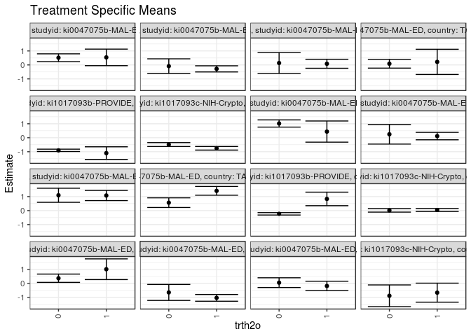

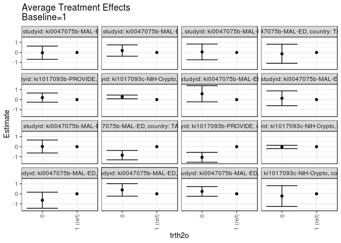

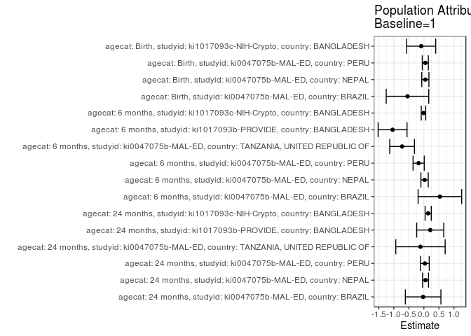

## Results Table

### Parameter: TSM

| agecat | studyid | country | intervention_level | baseline_level | estimate | ci_lower | ci_upper |
| --- | --- | --- | --- | --- | --- | --- | --- |
| Birth | ki0047075b-MAL-ED | BRAZIL | 1 | NA | 1.0133564 | 0.2733019 | 1.7534109 |
| Birth | ki0047075b-MAL-ED | BRAZIL | 0 | NA | 0.3700846 | 0.0731825 | 0.6669867 |
| Birth | ki0047075b-MAL-ED | NEPAL | 1 | NA | -1.0335977 | -1.2747483 | -0.7924471 |
| Birth | ki0047075b-MAL-ED | NEPAL | 0 | NA | -0.6450243 | -1.2176223 | -0.0724262 |
| Birth | ki0047075b-MAL-ED | PERU | 1 | NA | -0.1833333 | -0.5206097 | 0.1539430 |
| Birth | ki0047075b-MAL-ED | PERU | 0 | NA | 0.0533333 | -0.2938838 | 0.4005504 |
| Birth | ki1017093c-NIH-Crypto | BANGLADESH | 1 | NA | -0.6615670 | -1.3417834 | 0.0186493 |
| Birth | ki1017093c-NIH-Crypto | BANGLADESH | 0 | NA | -0.8856045 | -1.6621631 | -0.1090459 |
| 6 months | ki0047075b-MAL-ED | BRAZIL | 1 | NA | 0.4397063 | -0.3174011 | 1.1968137 |
| 6 months | ki0047075b-MAL-ED | BRAZIL | 0 | NA | 1.0203235 | 0.7620808 | 1.2785662 |
| 6 months | ki0047075b-MAL-ED | NEPAL | 1 | NA | 0.1177131 | -0.1480610 | 0.3834872 |
| 6 months | ki0047075b-MAL-ED | NEPAL | 0 | NA | 0.2475186 | -0.4543435 | 0.9493806 |
| 6 months | ki0047075b-MAL-ED | PERU | 1 | NA | 1.0775574 | 0.7124472 | 1.4426677 |
| 6 months | ki0047075b-MAL-ED | PERU | 0 | NA | 1.0955689 | 0.5913784 | 1.5997594 |
| 6 months | ki0047075b-MAL-ED | TANZANIA, UNITED REPUBLIC OF | 1 | NA | 1.4100000 | 1.0960519 | 1.7239481 |
| 6 months | ki0047075b-MAL-ED | TANZANIA, UNITED REPUBLIC OF | 0 | NA | 0.5646759 | 0.2190799 | 0.9102720 |
| 6 months | ki1017093b-PROVIDE | BANGLADESH | 1 | NA | 0.8326635 | 0.3479735 | 1.3173535 |
| 6 months | ki1017093b-PROVIDE | BANGLADESH | 0 | NA | -0.2323354 | -0.3171395 | -0.1475313 |
| 6 months | ki1017093c-NIH-Crypto | BANGLADESH | 1 | NA | 0.0428138 | -0.0625411 | 0.1481686 |
| 6 months | ki1017093c-NIH-Crypto | BANGLADESH | 0 | NA | 0.0147462 | -0.1111511 | 0.1406436 |
| 24 months | ki0047075b-MAL-ED | BRAZIL | 1 | NA | 0.5386660 | -0.0529839 | 1.1303158 |
| 24 months | ki0047075b-MAL-ED | BRAZIL | 0 | NA | 0.5147037 | 0.2356005 | 0.7938068 |
| 24 months | ki0047075b-MAL-ED | NEPAL | 1 | NA | -0.2825005 | -0.5014999 | -0.0635012 |
| 24 months | ki0047075b-MAL-ED | NEPAL | 0 | NA | -0.0879633 | -0.6106954 | 0.4347687 |
| 24 months | ki0047075b-MAL-ED | PERU | 1 | NA | 0.0814044 | -0.2406882 | 0.4034969 |
| 24 months | ki0047075b-MAL-ED | PERU | 0 | NA | 0.1366315 | -0.6132461 | 0.8865091 |
| 24 months | ki0047075b-MAL-ED | TANZANIA, UNITED REPUBLIC OF | 1 | NA | 0.2166667 | -0.6845675 | 1.1179009 |
| 24 months | ki0047075b-MAL-ED | TANZANIA, UNITED REPUBLIC OF | 0 | NA | 0.0854054 | -0.2281139 | 0.3989247 |
| 24 months | ki1017093b-PROVIDE | BANGLADESH | 1 | NA | -1.0997809 | -1.5503646 | -0.6491971 |
| 24 months | ki1017093b-PROVIDE | BANGLADESH | 0 | NA | -0.9020421 | -0.9862939 | -0.8177902 |
| 24 months | ki1017093c-NIH-Crypto | BANGLADESH | 1 | NA | -0.7539380 | -0.8820086 | -0.6258674 |
| 24 months | ki1017093c-NIH-Crypto | BANGLADESH | 0 | NA | -0.4893486 | -0.6286815 | -0.3500158 |

### Parameter: E(Y)

| agecat | studyid | country | intervention_level | baseline_level | estimate | ci_lower | ci_upper |
| --- | --- | --- | --- | --- | --- | --- | --- |
| Birth | ki0047075b-MAL-ED | BRAZIL | NA | NA | 0.4682716 | 0.1940109 | 0.7425323 |
| Birth | ki0047075b-MAL-ED | NEPAL | NA | NA | -0.9847541 | -1.2066471 | -0.7628611 |
| Birth | ki0047075b-MAL-ED | PERU | NA | NA | -0.1360000 | -0.4160147 | 0.1440147 |
| Birth | ki1017093c-NIH-Crypto | BANGLADESH | NA | NA | -0.7508696 | -1.2358912 | -0.2658480 |
| 6 months | ki0047075b-MAL-ED | BRAZIL | NA | NA | 0.9728964 | 0.7346428 | 1.2111501 |
| 6 months | ki0047075b-MAL-ED | NEPAL | NA | NA | 0.1409639 | -0.1073951 | 0.3893228 |
| 6 months | ki0047075b-MAL-ED | PERU | NA | NA | 0.9037755 | 0.5863704 | 1.2211806 |
| 6 months | ki0047075b-MAL-ED | TANZANIA, UNITED REPUBLIC OF | NA | NA | 0.6854365 | 0.3724525 | 0.9984205 |
| 6 months | ki1017093b-PROVIDE | BANGLADESH | NA | NA | -0.2083706 | -0.2927992 | -0.1239419 |
| 6 months | ki1017093c-NIH-Crypto | BANGLADESH | NA | NA | 0.0297622 | -0.0491685 | 0.1086930 |
| 24 months | ki0047075b-MAL-ED | BRAZIL | NA | NA | 0.5139320 | 0.2565665 | 0.7712976 |
| 24 months | ki0047075b-MAL-ED | NEPAL | NA | NA | -0.2262651 | -0.4277663 | -0.0247638 |
| 24 months | ki0047075b-MAL-ED | PERU | NA | NA | 0.1145918 | -0.1849945 | 0.4141781 |
| 24 months | ki0047075b-MAL-ED | TANZANIA, UNITED REPUBLIC OF | NA | NA | 0.1037209 | -0.1942394 | 0.4016813 |
| 24 months | ki1017093b-PROVIDE | BANGLADESH | NA | NA | -0.8879412 | -0.9708680 | -0.8050144 |
| 24 months | ki1017093c-NIH-Crypto | BANGLADESH | NA | NA | -0.6103502 | -0.7050157 | -0.5156847 |

### Parameter: ATE

| agecat | studyid | country | intervention_level | baseline_level | estimate | ci_lower | ci_upper |
| --- | --- | --- | --- | --- | --- | --- | --- |
| Birth | ki0047075b-MAL-ED | BRAZIL | 1 | 1 | 0.0000000 | 0.0000000 | 0.0000000 |
| Birth | ki0047075b-MAL-ED | BRAZIL | 0 | 1 | -0.6432718 | -1.4480401 | 0.1614965 |
| Birth | ki0047075b-MAL-ED | NEPAL | 1 | 1 | 0.0000000 | 0.0000000 | 0.0000000 |
| Birth | ki0047075b-MAL-ED | NEPAL | 0 | 1 | 0.3885734 | -0.2380536 | 1.0152005 |
| Birth | ki0047075b-MAL-ED | PERU | 1 | 1 | 0.0000000 | 0.0000000 | 0.0000000 |
| Birth | ki0047075b-MAL-ED | PERU | 0 | 1 | 0.2366667 | -0.2473943 | 0.7207277 |
| Birth | ki1017093c-NIH-Crypto | BANGLADESH | 1 | 1 | 0.0000000 | 0.0000000 | 0.0000000 |
| Birth | ki1017093c-NIH-Crypto | BANGLADESH | 0 | 1 | -0.2240375 | -1.2583768 | 0.8103018 |
| 6 months | ki0047075b-MAL-ED | BRAZIL | 1 | 1 | 0.0000000 | 0.0000000 | 0.0000000 |
| 6 months | ki0047075b-MAL-ED | BRAZIL | 0 | 1 | 0.5806172 | -0.2278608 | 1.3890952 |
| 6 months | ki0047075b-MAL-ED | NEPAL | 1 | 1 | 0.0000000 | 0.0000000 | 0.0000000 |
| 6 months | ki0047075b-MAL-ED | NEPAL | 0 | 1 | 0.1298055 | -0.6114879 | 0.8710988 |
| 6 months | ki0047075b-MAL-ED | PERU | 1 | 1 | 0.0000000 | 0.0000000 | 0.0000000 |
| 6 months | ki0047075b-MAL-ED | PERU | 0 | 1 | 0.0180115 | -0.6315039 | 0.6675268 |
| 6 months | ki0047075b-MAL-ED | TANZANIA, UNITED REPUBLIC OF | 1 | 1 | 0.0000000 | 0.0000000 | 0.0000000 |
| 6 months | ki0047075b-MAL-ED | TANZANIA, UNITED REPUBLIC OF | 0 | 1 | -0.8453241 | -1.3122289 | -0.3784193 |
| 6 months | ki1017093b-PROVIDE | BANGLADESH | 1 | 1 | 0.0000000 | 0.0000000 | 0.0000000 |
| 6 months | ki1017093b-PROVIDE | BANGLADESH | 0 | 1 | -1.0649989 | -1.5569253 | -0.5730724 |
| 6 months | ki1017093c-NIH-Crypto | BANGLADESH | 1 | 1 | 0.0000000 | 0.0000000 | 0.0000000 |
| 6 months | ki1017093c-NIH-Crypto | BANGLADESH | 0 | 1 | -0.0280675 | -0.1917050 | 0.1355700 |
| 24 months | ki0047075b-MAL-ED | BRAZIL | 1 | 1 | 0.0000000 | 0.0000000 | 0.0000000 |
| 24 months | ki0047075b-MAL-ED | BRAZIL | 0 | 1 | -0.0239623 | -0.6862807 | 0.6383561 |
| 24 months | ki0047075b-MAL-ED | NEPAL | 1 | 1 | 0.0000000 | 0.0000000 | 0.0000000 |
| 24 months | ki0047075b-MAL-ED | NEPAL | 0 | 1 | 0.1945372 | -0.3736480 | 0.7627224 |
| 24 months | ki0047075b-MAL-ED | PERU | 1 | 1 | 0.0000000 | 0.0000000 | 0.0000000 |
| 24 months | ki0047075b-MAL-ED | PERU | 0 | 1 | 0.0552271 | -0.7306956 | 0.8411498 |
| 24 months | ki0047075b-MAL-ED | TANZANIA, UNITED REPUBLIC OF | 1 | 1 | 0.0000000 | 0.0000000 | 0.0000000 |
| 24 months | ki0047075b-MAL-ED | TANZANIA, UNITED REPUBLIC OF | 0 | 1 | -0.1312613 | -1.0854716 | 0.8229491 |
| 24 months | ki1017093b-PROVIDE | BANGLADESH | 1 | 1 | 0.0000000 | 0.0000000 | 0.0000000 |
| 24 months | ki1017093b-PROVIDE | BANGLADESH | 0 | 1 | 0.1977388 | -0.2622547 | 0.6577324 |
| 24 months | ki1017093c-NIH-Crypto | BANGLADESH | 1 | 1 | 0.0000000 | 0.0000000 | 0.0000000 |
| 24 months | ki1017093c-NIH-Crypto | BANGLADESH | 0 | 1 | 0.2645894 | 0.0766142 | 0.4525645 |

### Parameter: PAR

| agecat | studyid | country | intervention_level | baseline_level | estimate | ci_lower | ci_upper |
| --- | --- | --- | --- | --- | --- | --- | --- |
| Birth | ki0047075b-MAL-ED | BRAZIL | 1 | NA | -0.5450848 | -1.2532961 | 0.1631266 |
| Birth | ki0047075b-MAL-ED | NEPAL | 1 | NA | 0.0488436 | -0.0698900 | 0.1675772 |
| Birth | ki0047075b-MAL-ED | PERU | 1 | NA | 0.0473333 | -0.0534388 | 0.1481054 |
| Birth | ki1017093c-NIH-Crypto | BANGLADESH | 1 | NA | -0.0893025 | -0.5723129 | 0.3937079 |
| 6 months | ki0047075b-MAL-ED | BRAZIL | 1 | NA | 0.5331901 | -0.1918924 | 1.2582727 |
| 6 months | ki0047075b-MAL-ED | NEPAL | 1 | NA | 0.0232508 | -0.0980809 | 0.1445824 |
| 6 months | ki0047075b-MAL-ED | PERU | 1 | NA | -0.1737819 | -0.3592428 | 0.0116790 |
| 6 months | ki0047075b-MAL-ED | TANZANIA, UNITED REPUBLIC OF | 1 | NA | -0.7245635 | -1.1348822 | -0.3142448 |
| 6 months | ki1017093b-PROVIDE | BANGLADESH | 1 | NA | -1.0410341 | -1.5214881 | -0.5605801 |
| 6 months | ki1017093c-NIH-Crypto | BANGLADESH | 1 | NA | -0.0130515 | -0.0875997 | 0.0614967 |
| 24 months | ki0047075b-MAL-ED | BRAZIL | 1 | NA | -0.0247339 | -0.6161148 | 0.5666469 |
| 24 months | ki0047075b-MAL-ED | NEPAL | 1 | NA | 0.0562355 | -0.0428615 | 0.1553324 |
| 24 months | ki0047075b-MAL-ED | PERU | 1 | NA | 0.0331874 | -0.1119312 | 0.1783061 |
| 24 months | ki0047075b-MAL-ED | TANZANIA, UNITED REPUBLIC OF | 1 | NA | -0.1129457 | -0.9341257 | 0.7082342 |
| 24 months | ki1017093b-PROVIDE | BANGLADESH | 1 | NA | 0.2118397 | -0.2383662 | 0.6620456 |
| 24 months | ki1017093c-NIH-Crypto | BANGLADESH | 1 | NA | 0.1435878 | 0.0413626 | 0.2458130 |